# BE2_ProcessusGaussiens_MESSINA_MUNOZ

MESSINA Valentin et MUNOZ Eloi

Dans ce TP, on se donne a priori $\theta = \theta_{ref} =0.15$ et $\sigma^2 = \sigma^2_{ref} = 1$ et on cherche à estimer $\theta$ à l’aide trois différentes méthodes : d’abord on va calculer un variogramme empirique et chercher la valeur de $\theta$ qui donne un variogramme théorique le plus proche possible. Ensuite, on va estimer $\theta$ par validation croisée avec une méthode LOO (Leave One Out) et enfin on l’estimera par maximum de vraisemblance.

Pour commencer, on réalise une simulation non conditionnelle.

**Simulation non conditionnelle**

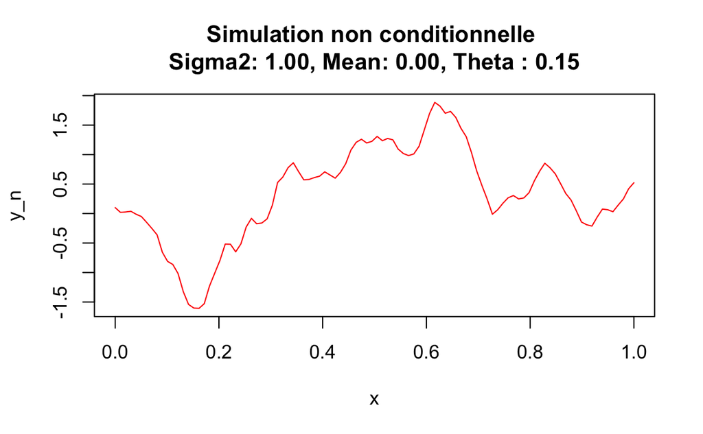

```r
m <- 0
theta <- 0.15
sigma2 <- 1
n_points <- 100
x <- seq(0, 0.4, length.out = n_points)

matern_cov <- function(x1, x2, theta) {
  p <- length(x1)
  result <- 1

  for (j in 1:p) {
    term1 <- (1 + (sqrt(5) * abs(x1[j] - x2[j]) / theta[j]) - (5/3) * ((x1[j] - x2[j])^2 / theta[j]^2))
    term2 <- exp(-sqrt(5) * abs(x1[j] - x2[j]) / theta[j])
    result <- result * (term1 * term2)
  }

  return(result)
}

x <- seq(0, 1, length.out = n_points)

matrice_covariance <- matrix(0, n_points, n_points)

for (i in 1:n_points) {
  for (j in 1:n_points) {
    matrice_covariance[i, j] <- matern_cov(x[i], x[j], theta)
  }
}

matrice_covariance <- matrice_covariance * sigma2

simulate_non_conditional <- function(mean_vector, covariance_matrix, n_simulations) {
  L <- chol(covariance_matrix)
  u <- matrix(rnorm(n_points * n_simulations), n_points, n_simulations)
  simulated_values <- matrix(mean_vector, nrow = n_points, ncol = n_simulations) + t(L) %*% u
  return(simulated_values)
}

n_simulations <- 1
mean_vector <- rep(m, n_points)
covariance_matrix <- matrice_covariance

simulated_values <- simulate_non_conditional(mean_vector, covariance_matrix, n_simulations)

matplot(x, simulated_values, type = "l", col = rainbow(n_simulations), xlab = "x", ylab = "y_n",
        main = sprintf("Simulation non conditionnelle \nSigma2: %.2f, Mean: %.2f, Theta : %.2f", sigma2, m, theta))
```

- **Méthode 1 :** variogramme empirique

```r
selected_values <- simulated_values[ seq(1, n_points, by = 2),]
selected_x <- x[ seq(1, n_points, by = 2)]

abs_diff_matrix <- matrix(0, nrow = length(selected_x), ncol = length(selected_x))

for (i in 1:length(selected_x)) {
  for (j in 1:length(selected_x)) {
    abs_diff_matrix[i, j] <- abs(selected_x[i] - selected_x[j])
  }
}

squared_diff_matrix <- matrix(0, nrow = length(selected_values), ncol = length(selected_values))

for (i in 1:length(selected_values)) {
  for (j in 1:length(selected_values)) {
    squared_diff_matrix[i, j] <- 0.5 * (selected_values[i] - selected_values[j])^2
  }
}

unique_values <- unique(as.vector(round(abs_diff_matrix, 8)))

sig_hat2 <- numeric()

for (value in unique_values) {
  indices <- which(round(abs_diff_matrix, 8) == value, arr.ind = TRUE)
  filtered_indices <- indices[indices[, 1] < indices[, 2], ]
  sum_squared_diff <- sum(squared_diff_matrix[filtered_indices])
  average_value <- sum_squared_diff / as.numeric(dim(filtered_indices)[1])
  sig_hat2 <- c(sig_hat2, average_value)
}

num_points <- length(unique_values)
num_to_plot <- round(0.4 * num_points)

filtered_values <- unique_values[1:num_to_plot]
filtered_sig_hat2 <- sig_hat2[1:num_to_plot]

plot(filtered_values, filtered_sig_hat2, pch = 16, col = "blue",
     xlab = "h_empirical", ylab = "sig_hat2",
     main = "Variogramme empirique vs théorique")

#valeurs de theta pour Variogramme
theta_values <- seq(0, 2, length.out = 20)

matern_cov_values <- matrix(0, nrow = length(filtered_values), ncol = length(theta_values))

for (i in 1:length(theta_values)) {
  for (j in 1:length(filtered_values)) {
    matern_cov_values[j, i] <- sigma2*(1- matern_cov(0, filtered_values[j], theta_values[i]))
  }
}

colors <- rainbow(length(theta_values)) # Couleurs pour chaque courbe
for (i in 1:length(theta_values)) {
  lines(filtered_values, matern_cov_values[,i], col = colors[i], type = "l", lwd = 2,
        xlab = "Lag Distance", ylab = "Matern Cov", main = "Matern Cov vs Lag Distance")
}
```

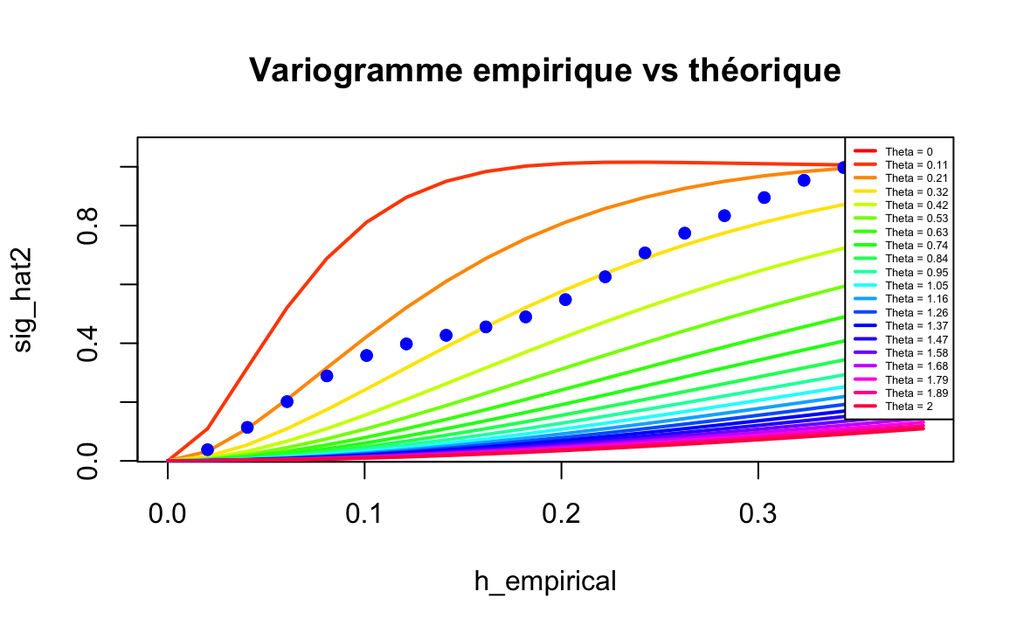

```r
points(filtered_values, filtered_sig_hat2, pch = 16, col = "blue")

legend_values <- paste("Theta =", round(theta_values, 2))
legend_colors <- colors
legend("topright", legend = legend_values, col = legend_colors, lty = 1, lwd = 2, bg = "white", inset = 0, cex=0.4)
```

- **Méthode 2 :** estimation par validation croisée LOO (Leave One Out)

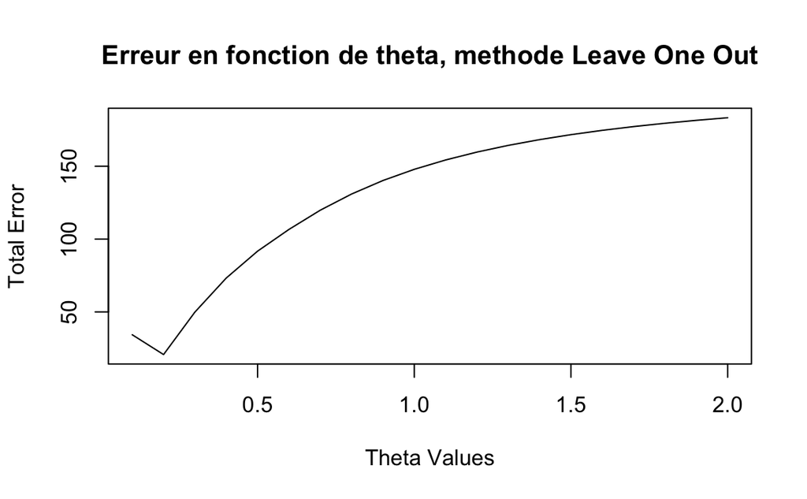

```r
simple_kriging_predictor <- function(x0, x, y, cov_matrix, mean_vector,theta) {
  n <- length(x)
  k <- sapply(x, function(xi) matern_cov(x0, xi, theta))
  k0 <- sapply(x0, function(xi) matern_cov(xi, xi, theta))
  weights <- solve(cov_matrix, k)

  predictor <- mean_vector + sum(weights * (y - mean_vector))
  variance <- k0 - sum(weights * k)

  return(list(predictor = predictor, variance = variance))
}

# Définir les valeurs de theta à tester
theta_values <- seq(0.1, 2, by = 0.1)

total_errors <- numeric(length(theta_values))

for (i in seq_along(theta_values)) {
  thet <- theta_values[i]

  total_error <- 0

  for (j in 1:n_points) {
    selected_points <- seq_len(n_points)[-j]  # Sélectionner tous les points sauf le j-ème
    selected_values <- simulated_values[-j]   # Sélectionner toutes les valeurs sauf la j-ème

    prediction <- simple_kriging_predictor(x[j], x[selected_points], selected_values, matrice_covariance[selected_points, selected_points], mean_vector[selected_points],thet)

    total_error <- total_error + abs(simulated_values[j] - prediction$predictor[1])
  }

  total_errors[i] <- total_error
}

plot(theta_values, total_errors, type = "l", xlab = "Theta Values", ylab = "Total Error",
     main = "Erreur en fonction de theta, methode Leave One Out")
```

On voit que le graphe de l’erreur en fonction de $\theta$ admet bien un minimum proche de $\theta_{ref}$ donc on valide la méthode.

- **Méthode 3 :** Maximum de vraisemblance

```r
n <- n_points
y_n <- simulated_values
initial_theta <- 0.001

matern_cov <- function(x1, x2, theta) {
  p <- length(x1)
  result <- 1

  for (j in 1:p) {
    term1 <- (1 + (sqrt(5) * abs(x1[j] - x2[j]) / theta[j]) - (5/3) * ((x1[j] - x2[j])^2 / theta[j]^2))
    term2 <- exp(-sqrt(5) * abs(x1[j] - x2[j]) / theta[j])
    result <- result * (term1 * term2)
  }

  return(result)
}

matrice_cov <- function(theta){
  matrice_covariance <- matrix(0, n_points, n_points)

  for (i in 1:n_points) {
    for (j in 1:n_points) {
    matrice_covariance[i, j] <- matern_cov(x[i], x[j], theta)
    }
  }
   matrice_covariance <- matrice_covariance *
   return(matrice_covariance)
}

# Fonction log-vraisemblance
log_likelihood <- function(theta, n, y_n) {
  R_theta <- matrice_cov(theta)
  one_v <- numeric(n) + 1
m_hat_MEV <- solve(t(one_v) %*% solve(R_theta) %*% one_v) %*% t(one_v) %*% solve(R_theta) %*% y_n
sigma2_hat_MEV <- (1/n) * t(y_n - m_hat_MEV * one_v) %*% solve(R_theta) %*% (y_n - m_hat_MEV * one_v)

  # Calculer la log-vraisemblance
  log_likelihood_value <- (n/2) * log(2 * pi * sigma2_hat_MEV) + (1/2) * log(det(R_theta)) + (n/2)
  return(-log_likelihood_value)  # La fonction d'optimisation minimise, donc on utilise -log_likelihood
}

# Trouver le theta optimal
result <- optim(par = initial_theta, fn = log_likelihood, n = n, y_n = y_n)
```

[output not shown]

[output cut: 58 more lines]

[output not shown]

```r
theta_optimal_EMV <- result$par
# Afficher la valeur de theta optimal
cat("Theta optimal:", theta_optimal_EMV, "\n")
```

```
Theta optimal: 0.00465625
```

```r
ini_theta <- rep(0, length(initial_theta))  # Remplacez par une valeur initiale appropriée

# Afficher la valeur pour theta variant entre 0 et 1
theta_values <- seq(initial_theta, 1, length.out = 100)
log_likelihood_values <- sapply(theta_values, function(theta_val) -log_likelihood(theta_val, n, y_n))
```

[output not shown]

[output cut: 345 more lines]

[output not shown]

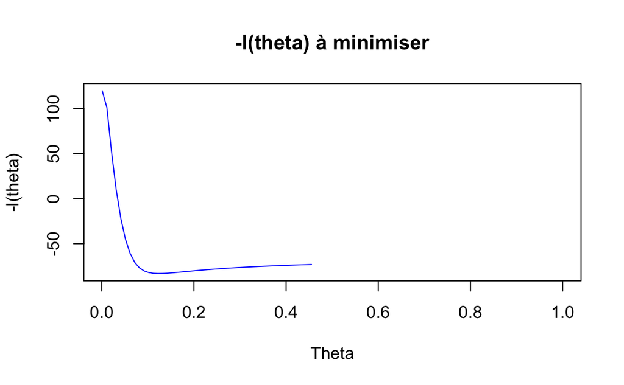

```r
plot(theta_values, log_likelihood_values, type = "l", col = "blue", xlab = "Theta", ylab = "-l(theta)", main ="-l(theta) à minimiser")
```

Ici, on voit que la méthode fonctionne car le graphe de l’opposé de la vraisemblance restreinte admet bien un minimum proche de $\theta_{ref}$ mais le minimum n’est pas évident et la fonction optim de R donne une valeur erronée.